# intro_to_python

## Introduction to Python

Python is a programming language that can be used in innumerable ways.

Some of the ways that Python applies to journalism.

- Analyze and visualize data
- Scrape websites and PDFs
- Build and manage databases

Some of the advanatages of Python over using Google Sheets include versatility (it's a full-blown programming language) reproducibility and sharability. Once you create a notebook, it's easy to go back to track each step of your work.

### Start with variables

We will start with learning about variables. A variable is like a container. You can assign a value.

[figure not shown]

*Whatever is on the right side, will be stuffed into the left side.*

Let's try it. Let's stuff the number 7 into x. Put your cursor in the box below, hold the shift key down, and press return.

```python
x = 7
```

Next, let's see the output. We'll type just "x" by itself and Python will output its value. In each of these boxes, put your cursor in the box, hold down the shift key on your keyboard, and press return.

```python
x
```

```
7
```

One shortcut, we can combine both statements into one, so that when we set a variable, we can immediately see its output. Let's try:

```python
k = 5
k
```

```
5
```

This is common in the tasks we'll do later. We'll list a variable by itself immediately after we set it so that it will show us the output.

Here is something else we can do, we can replace the value in variables. When we do, it takes its most recent assignment.

```python
j = 3
j = 5
j
```

```
5
```

Notice how j is equal to 5 and not three. We replaced its value by assigning a new value.

By the way, how is that x doing?

```python
x = 10
x
```

```
10
```

```python
x
```

```
10
```

So, the order of operations matters. The order in which we run each Python line of code makes a difference. Notice those numbers beside each cell? That describes the order we ran each cell so we can keep track of what was done.

Next, let's see how we can assign variables to other variables.

```python
x = 3
y = x
y
```

```
3
```

```python
x = 3
y = "x"
y
```

```
'x'
```

Ah hah! We assigned text string "x" to y, so y now stores the value of a piece of text. If we left the quotes off, it would assign the *value* of x rather than the string "x". Important distinction.

Here are some other things we can do:

```python
x = 2 + 2
x
```

```
4
```

```python
x = 5
y = 1
j = x + y
j
```

```
6
```

Let's try something different. What would happen if we added two strings together? Any guesses? Guess what might happen before we run the code below. The run it to see if you were right.

```python
firstname = "Jeremy"
lastname  = "Rue"
fullname  = firstname + lastname
fullname
```

```
'JeremyRue'
```

### Lists

There is a special type of variable in Python called lists. It's pretty cool. It gives us the ability to store multiple values in a single variable. Let's take a look:

```python
months = ["January", "February", "March", "April", "May", "June", "July", "August", "September", "October", "November"]
months
```

```
['January',
 'February',
 'March',
 'April',
 'May',
 'June',
 'July',
 'August',
 'September',
 'October',
 'November']
```

Notice the output simply lists the values in the list. How do we recall a value? We use something called the **zero index**, which starts with zero as the first value, and so on?

Take a guess, what will the following output?

```python
months[0]
```

```
'January'
```

What about this one?

```python
months[1]
```

```
'February'
```

OK, one more time... before running this code, take a guess, what will this output?

```python
months[5]
```

```
'June'
```

There are also special commands called "methods" we can run on lists.

We can ask this list how long it is:

```python
len(months)
```

```
11
```

We can also append (add to) the list, even though we already assigned the values.

```python
months.append('December')
len(months)
```

```
12
```

We can also extract a portion, or slice, of this list using special notation.

```python
months[0:3]
```

```
['January', 'February', 'March']
```

Note that the zero referred to the first item, but the second number referrs to the item before the index. Here is a nifty guide to refer to if you ever forget:

```
a[start:stop] # items start until stop - 1
a[start:]     # items start then go through the rest of the list
a[:stop]      # items from the beginning until stop - 1
a[:]          # a copy of the whole list

a[start:stop:step] # start, but do not past stop, by step
```

Try a few of these from above yourself in the next cell:

```python
months[0:5:2]
```

```
['January', 'March', 'May']
```

### Dictionaries

The next datatype is dictionaries. Dictionaries are similar to JSON, which we'll go over later in class.

The important thing to know about dictionaries is they store values by properties called "keys" (similar to CSS).

```python
# Curly braces! Not brackets

my_dict = {
    "city": "Berkeley",
    "state": "California",
    "county": "Alameda",
    "zip": 94720
}

my_dict
```

```
{'city': 'Berkeley', 'state': 'California', 'county': 'Alameda', 'zip': 94720}
```

We can recall any value by its keys using notation similar to lists, but putting the property string instead of an index.

```python
my_dict["city"]
```

```
'Berkeley'
```

```python
my_dict["zip"]
```

```
94720
```

```python
my_dict.keys()
```

```
dict_keys(['city', 'state', 'county', 'zip'])
```

```python
my_dict.values()
```

```
dict_values(['Berkeley', 'California', 'Alameda', 94720])
```

## Importing Libraries

Okay, now that we have all of that out of the way, we will do some data stuff. The first thing we need to do is import some libraries. We will use the popular Pandas library, and also import Seaborn for doing some basic data visaulizations. These libraries were installed prior to this lesson, so you don't have to install them. But if you were doing this on your own, you'd need to install them before running the code below.

```python
import numpy as np
import pandas as pd
import seaborn as sns
import matplotlib.pyplot as plt
```

Now that we've imported our libraries, let's bring in our .csv file using pandas. Notice above, our Pandas library was stored in a variable called "pd" (short for Pandas). Technically, we could have specified anything for our Pandas library, but pd is the standard convention, so let's stick with that.

```python
pulitzers = pd.read_csv("pulitzer-circulation-data.csv", encoding='utf-8')
```

Now, let's take a look and see what it looks like. We can run the command `head()` on the variable to see the first five rows of data.

```python
pulitzers.head()
```

|  | Newspaper | Daily Circulation, 2004 | Daily Circulation, 2013 | Change in Daily Circulation, 2004-2013 in Percent | Pulitzer Prize Winners and Finalists, 1990-2003 | Pulitzer Prize Winners and Finalists, 2004-2014 | Pulitzer Prize Winners and Finalists, 1990-2014 |
| --- | --- | --- | --- | --- | --- | --- | --- |
| 0 | USA Today | 2192098 | 1674306 | -24 | 1 | 1 | 2 |
| 1 | Wall Street Journal | 2101017 | 2378827 | 13 | 30 | 20 | 50 |
| 2 | New York Times | 1119027 | 1865318 | 67 | 55 | 62 | 117 |
| 3 | Los Angeles Times | 983727 | 653868 | -34 | 44 | 41 | 85 |
| 4 | Washington Post | 760034 | 474767 | -38 | 52 | 48 | 100 |

We can also put a number in the parenthesis to specify a specific number of rows to show.

```python
pulitzers.head(10)
```

|  | Newspaper | Daily Circulation, 2004 | Daily Circulation, 2013 | Change in Daily Circulation, 2004-2013 in Percent | Pulitzer Prize Winners and Finalists, 1990-2003 | Pulitzer Prize Winners and Finalists, 2004-2014 | Pulitzer Prize Winners and Finalists, 1990-2014 |
| --- | --- | --- | --- | --- | --- | --- | --- |
| 0 | USA Today | 2192098 | 1674306 | -24 | 1 | 1 | 2 |
| 1 | Wall Street Journal | 2101017 | 2378827 | 13 | 30 | 20 | 50 |
| 2 | New York Times | 1119027 | 1865318 | 67 | 55 | 62 | 117 |
| 3 | Los Angeles Times | 983727 | 653868 | -34 | 44 | 41 | 85 |
| 4 | Washington Post | 760034 | 474767 | -38 | 52 | 48 | 100 |
| 5 | New York Daily News | 712671 | 516165 | -28 | 4 | 2 | 6 |
| 6 | New York Post | 642844 | 500521 | -22 | 0 | 0 | 0 |
| 7 | Chicago Tribune | 603315 | 414930 | -31 | 23 | 15 | 38 |
| 8 | San Jose Mercury News | 558874 | 583998 | 4 | 4 | 2 | 6 |
| 9 | Newsday | 553117 | 377744 | -32 | 12 | 6 | 18 |

### Interview Functions

Let's interview our data. Here are some functions we can run. The "df" is a placeholder for your data. It's stands for "data frame" which is what we call this datatype when using Pandas.

`df.head()` - get the first 5 rows of your data (or specify number)

`df.tail()` - get the last 5 rows of your data (or specify number)

`df.sample(5)` - get a random sampling of 5 rows of your data

`df.columns` - get a list of all the columns

`df.info()` - get number of rows with data and data type for each column

`df.shape` - get the number of rows and columns

`df.describe()` - get a variety of statistical calculations for all values in each column

Let's take these functions for a spin:

```python
#also try pulitzers.columns[2:5]
pulitzers.columns
```

```
Index(['Newspaper', 'Daily Circulation, 2004', 'Daily Circulation, 2013',
       'Change in Daily Circulation, 2004-2013 in Percent',
       'Pulitzer Prize Winners and Finalists, 1990-2003',
       'Pulitzer Prize Winners and Finalists, 2004-2014',
       'Pulitzer Prize Winners and Finalists, 1990-2014'],
      dtype='object')
```

```python
#describes the number of rows and columns
pulitzers.shape
```

```
(50, 7)
```

```python
pulitzers.describe()
```

|  | Daily Circulation, 2004 | Daily Circulation, 2013 | Change in Daily Circulation, 2004-2013 in Percent | Pulitzer Prize Winners and Finalists, 1990-2003 | Pulitzer Prize Winners and Finalists, 2004-2014 | Pulitzer Prize Winners and Finalists, 1990-2014 |
| --- | --- | --- | --- | --- | --- | --- |
| count | 5.000000e+01 | 5.000000e+01 | 50.000000 | 50.000000 | 50.000000 | 50.000000 |
| mean | 4.624217e+05 | 3.624628e+05 | -29.200000 | 8.340000 | 6.720000 | 15.060000 |
| std | 3.965849e+05 | 4.404812e+05 | 27.066811 | 12.886649 | 12.142084 | 24.640609 |
| min | 2.157350e+05 | 0.000000e+00 | -100.000000 | 0.000000 | 0.000000 | 0.000000 |
| 25% | 2.598472e+05 | 1.617345e+05 | -40.750000 | 1.000000 | 1.000000 | 2.000000 |
| 50% | 3.400875e+05 | 2.293365e+05 | -32.500000 | 4.000000 | 3.000000 | 7.000000 |
| 75% | 4.909875e+05 | 3.733708e+05 | -20.000000 | 9.750000 | 6.750000 | 15.250000 |
| max | 2.192098e+06 | 2.378827e+06 | 67.000000 | 55.000000 | 62.000000 | 117.000000 |

Note that we can also use dot-notation to call any column we want.

```python
pulitzers.Newspaper
```

```
0                        USA Today
1              Wall Street Journal
2                   New York Times
3                Los Angeles Times
4                  Washington Post
5              New York Daily News
6                    New York Post
7                  Chicago Tribune
8            San Jose Mercury News
9                          Newsday
10               Houston Chronicle
11             Dallas Morning News
12         San Francisco Chronicle
13                Arizona Republic
14               Chicago Sun-Times
```

[output cut: 36 more lines]

```python
pulitzers["Daily Circulation, 2013"]
```

```
0     1674306
1     2378827
2     1865318
3      653868
4      474767
5      516165
6      500521
7      414930
8      583998
9      377744
10     360251
11     409265
12     218987
13     293640
14     470548
```

[output cut: 36 more lines]

```python
pulitzers.info ()
```

```
<class 'pandas.core.frame.DataFrame'>
RangeIndex: 50 entries, 0 to 49
Data columns (total 7 columns):
 #   Column                                             Non-Null Count  Dtype
---  ------                                             --------------  -----
 0   Newspaper                                          50 non-null     object
 1   Daily Circulation, 2004                            50 non-null     int64
 2   Daily Circulation, 2013                            50 non-null     int64
 3   Change in Daily Circulation, 2004-2013 in Percent  50 non-null     int64
 4   Pulitzer Prize Winners and Finalists, 1990-2003    50 non-null     int64
 5   Pulitzer Prize Winners and Finalists, 2004-2014    50 non-null     int64
 6   Pulitzer Prize Winners and Finalists, 1990-2014    50 non-null     int64
dtypes: int64(6), object(1)
memory usage: 2.9+ KB
```

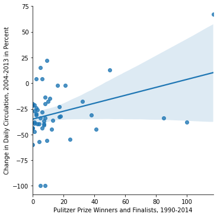

```python
sns.lmplot(
    x="Pulitzer Prize Winners and Finalists, 1990-2014",
    y="Change in Daily Circulation, 2004-2013 in Percent",
    data=pulitzers)
```

### Restaurant Inspections

```python
inspections = pd.read_csv("Restaurant_Inspections.csv")
inspections.head()
```

|  | Facility_ID | Facility_Name | Address | City | State | Zip | Violation_Description | Grade | Longitude | Latitude | Activity_Date |
| --- | --- | --- | --- | --- | --- | --- | --- | --- | --- | --- | --- |
| 0 | FA0323277 | HUNAN CUISINE | 6004 STEVENSON BLVD | FREMONT | CA | 94538 | Proper hot and cold holding temperatures | Y | -121.996649 | 37.507270 | 9/26/19 0:00 |
| 1 | FA0006859 | PAPAYA THAI | 6066 MOWRY AVE | NEWARK | CA | 94560 | Food contact surfaces: clean and sanitized | Y | -122.008966 | 37.522690 | 8/14/19 0:00 |
| 2 | FA0310088 | BJ'S RESTAURANT & BREWHOUSE | 5699 MOWRY AVE | NEWARK | CA | 94560 | Premises personal/cleaning items vermin-proofing | G | -122.006290 | 37.526743 | 12/17/18 0:00 |
| 3 | FA0305014 | LA FARFALLA | 39055 CEDAR BLVD 182 | NEWARK | CA | 94560 | Wiping cloths: properly used and stored | G | -122.005118 | 37.523591 | 3/25/19 0:00 |
| 4 | FA0306102 | SIA FUSION EATERY | 39263 CEDAR BLVD | NEWARK | CA | 94560 | Consumer advisory provided for raw or undercooked | G | -122.003482 | 37.522783 | 12/21/18 0:00 |

We can look at unique values for any column of data. Let's look at the Grade column to see what grades were given. (They correspond to colors)

```python
inspections.Grade.unique()
```

```
array(['Y', 'G', 'R'], dtype=object)
```

```python
inspections.groupby("Grade").Facility_ID.count()
```

```
Grade
G    41755
R     2756
Y     9035
Name: Facility_ID, dtype: int64
```

We can search by grade or by a name of a specific restaurant.

```python
inspections[inspections["Grade"] == "R"]
```

|  | Facility_ID | Facility_Name | Address | City | State | Zip | Violation_Description | Grade | Longitude | Latitude | Activity_Date |
| --- | --- | --- | --- | --- | --- | --- | --- | --- | --- | --- | --- |
| 16 | FA0000116 | 7-ELEVEN FOOD STORE #2369-18608E | 4100 BROADWAY | OAKLAND | CA | 94611 | Signs posted last inspection report available | R | -122.255708 | 37.829098 | 11/7/19 0:00 |
| 22 | FA0001150 | TAKARA SUSHI | 5897-99 COLLEGE AVE | OAKLAND | CA | 94618 | No rodents, insects, birds, or animals | R | -122.252079 | 37.847170 | 12/3/18 0:00 |
| 38 | FA0323158 | BLIND TIGER | 2600 TELEGRAPH AVE | OAKLAND | CA | 94612 | Food contact surfaces: clean and sanitized | R | -122.268005 | 37.815789 | 8/27/19 0:00 |
| 52 | FA0000448 | LAKEHURST HOTEL | 1569 JACKSON ST | OAKLAND | CA | 94612 | Floors, walls and ceilings: built, maintained,... | R | -122.264309 | 37.803529 | 9/28/18 0:00 |
| 95 | FA0004962 | BILL'S CAFE | 3015 HOPYARD RD #A-C | PLEASANTON | CA | 94588 | Proper hot and cold holding temperatures | R | -121.896882 | 37.676045 | 8/16/19 0:00 |
| ... | ... | ... | ... | ... | ... | ... | ... | ... | ... | ... | ... |
| 53473 | FA0003401 | MEHRAN RESTAURANT | 5774 MOWRY SCHOOL RD | NEWARK | CA | 94560 | Proper eating, tasting, drinking or tobacco use | R | -122.006519 | 37.526406 | 9/19/19 0:00 |
| 53485 | FA0003767 | LOVELY SWEETS & SNACKS | 41031 FREMONT BLVD | FREMONT | CA | 94538 | Adequate ventilation and lighting designated area | R | -121.958840 | 37.530919 | 9/10/18 0:00 |
| 53496 | FA0006107 | UNA MAS MEXICAN GRILL | 1476 FIRST ST | LIVERMORE | CA | 94550 | Permit Suspension | R | -121.777213 | 37.679128 | 8/27/18 0:00 |
| 53516 | FA0003791 | NEW YORK PIZZA PLEASANTON | 690 MAIN ST | PLEASANTON | CA | 94566 | Floors, walls and ceilings: built, maintained,... | R | -121.874833 | 37.662661 | 3/28/19 0:00 |
| 53523 | FA0003700 | BOTTLE SHOP | 40919 FREMONT BLVD | FREMONT | CA | 94538 | Floors, walls and ceilings: built, maintained,... | R | -121.961191 | 37.534046 | 11/1/18 0:00 |

2756 rows × 11 columns

```python
reds = inspections[inspections["Grade"] == "R"]
reds.groupby("City").count()
```

| City | Facility_ID | Facility_Name | Address | State | Zip | Violation_Description | Grade | Longitude | Latitude | Activity_Date |
| --- | --- | --- | --- | --- | --- | --- | --- | --- | --- | --- |
| ALAMEDA | 149 | 149 | 149 | 149 | 149 | 149 | 149 | 149 | 149 | 149 |
| ALBANY | 1 | 1 | 1 | 1 | 1 | 1 | 1 | 1 | 1 | 1 |
| CASTRO VALLEY | 29 | 29 | 29 | 29 | 29 | 29 | 29 | 29 | 29 | 29 |
| DUBLIN | 20 | 20 | 20 | 20 | 20 | 20 | 20 | 20 | 20 | 20 |
| EMERYVILLE | 37 | 37 | 37 | 37 | 37 | 37 | 37 | 37 | 37 | 37 |
| FREMONT | 370 | 370 | 370 | 370 | 370 | 370 | 370 | 370 | 370 | 370 |
| HAYWARD | 28 | 28 | 28 | 28 | 28 | 28 | 28 | 28 | 28 | 28 |
| LIVERMORE | 340 | 340 | 340 | 340 | 340 | 340 | 340 | 340 | 340 | 340 |
| NEWARK | 158 | 158 | 158 | 158 | 158 | 158 | 158 | 158 | 158 | 158 |
| OAKLAND | 970 | 970 | 970 | 970 | 970 | 970 | 970 | 970 | 970 | 970 |
| PLEASANTON | 306 | 306 | 306 | 306 | 306 | 306 | 306 | 306 | 306 | 306 |
| SAN LEANDRO | 26 | 26 | 26 | 26 | 26 | 26 | 26 | 26 | 26 | 26 |
| SUNOL | 15 | 15 | 15 | 15 | 15 | 15 | 15 | 15 | 15 | 15 |
| UNION CITY | 307 | 307 | 307 | 307 | 307 | 307 | 307 | 307 | 307 | 307 |

```python
inspections[inspections["Facility_Name"] == "BLIND TIGER"]
```

|  | Facility_ID | Facility_Name | Address | City | State | Zip | Violation_Description | Grade | Longitude | Latitude | Activity_Date |
| --- | --- | --- | --- | --- | --- | --- | --- | --- | --- | --- | --- |
| 38 | FA0323158 | BLIND TIGER | 2600 TELEGRAPH AVE | OAKLAND | CA | 94612 | Food contact surfaces: clean and sanitized | R | -122.268005 | 37.815789 | 8/27/19 0:00 |
| 4631 | FA0323158 | BLIND TIGER | 2600 TELEGRAPH AVE | OAKLAND | CA | 94612 | Food contact surfaces: clean and sanitized | G | -122.268005 | 37.815789 | 11/19/19 0:00 |
| 6498 | FA0323158 | BLIND TIGER | 2600 TELEGRAPH AVE | OAKLAND | CA | 94612 | No rodents, insects, birds, or animals | Y | -122.268005 | 37.815789 | 10/25/18 0:00 |
| 9230 | FA0323158 | BLIND TIGER | 2600 TELEGRAPH AVE | OAKLAND | CA | 94612 | Premises personal/cleaning items vermin-proofing | R | -122.268005 | 37.815789 | 8/27/19 0:00 |
| 12576 | FA0323158 | BLIND TIGER | 2600 TELEGRAPH AVE | OAKLAND | CA | 94612 | Food contact surfaces: clean and sanitized | R | -122.268005 | 37.815789 | 7/26/19 0:00 |
| 12782 | FA0323158 | BLIND TIGER | 2600 TELEGRAPH AVE | OAKLAND | CA | 94612 | Adequate handwashing facilities supplied & acc... | Y | -122.268005 | 37.815789 | 10/25/18 0:00 |
| 12783 | FA0323158 | BLIND TIGER | 2600 TELEGRAPH AVE | OAKLAND | CA | 94612 | Signs posted last inspection report available | Y | -122.268005 | 37.815789 | 10/25/18 0:00 |
| 14125 | FA0323158 | BLIND TIGER | 2600 TELEGRAPH AVE | OAKLAND | CA | 94612 | Food separated and protected | R | -122.268005 | 37.815789 | 7/26/19 0:00 |
| 15356 | FA0323158 | BLIND TIGER | 2600 TELEGRAPH AVE | OAKLAND | CA | 94612 | Adequate handwashing facilities supplied & acc... | R | -122.268005 | 37.815789 | 7/26/19 0:00 |
| 16180 | FA0323158 | BLIND TIGER | 2600 TELEGRAPH AVE | OAKLAND | CA | 94612 | Wiping cloths: properly used and stored | R | -122.268005 | 37.815789 | 8/27/19 0:00 |
| 17659 | FA0323158 | BLIND TIGER | 2600 TELEGRAPH AVE | OAKLAND | CA | 94612 | Floors, walls and ceilings: built, maintained,... | G | -122.268005 | 37.815789 | 11/19/19 0:00 |
| 20686 | FA0323158 | BLIND TIGER | 2600 TELEGRAPH AVE | OAKLAND | CA | 94612 | Floors, walls and ceilings: built, maintained,... | G | -122.268005 | 37.815789 | 11/6/18 0:00 |
| 21109 | FA0323158 | BLIND TIGER | 2600 TELEGRAPH AVE | OAKLAND | CA | 94612 | No rodents, insects, birds, or animals | G | -122.268005 | 37.815789 | 11/6/18 0:00 |
| 21866 | FA0323158 | BLIND TIGER | 2600 TELEGRAPH AVE | OAKLAND | CA | 94612 | Proper cooling methods | G | -122.268005 | 37.815789 | 11/19/19 0:00 |
| 22713 | FA0323158 | BLIND TIGER | 2600 TELEGRAPH AVE | OAKLAND | CA | 94612 | Wiping cloths: properly used and stored | Y | -122.268005 | 37.815789 | 10/25/18 0:00 |
| 23142 | FA0323158 | BLIND TIGER | 2600 TELEGRAPH AVE | OAKLAND | CA | 94612 | Adequate ventilation and lighting designated area | G | -122.268005 | 37.815789 | 11/19/19 0:00 |
| 24409 | FA0323158 | BLIND TIGER | 2600 TELEGRAPH AVE | OAKLAND | CA | 94612 | Signs posted last inspection report available | R | -122.268005 | 37.815789 | 8/27/19 0:00 |
| 25605 | FA0323158 | BLIND TIGER | 2600 TELEGRAPH AVE | OAKLAND | CA | 94612 | Adequate ventilation and lighting designated area | R | -122.268005 | 37.815789 | 7/26/19 0:00 |
| 27989 | FA0323158 | BLIND TIGER | 2600 TELEGRAPH AVE | OAKLAND | CA | 94612 | No rodents, insects, birds, or animals | R | -122.268005 | 37.815789 | 8/27/19 0:00 |
| 28460 | FA0323158 | BLIND TIGER | 2600 TELEGRAPH AVE | OAKLAND | CA | 94612 | No rodents, insects, birds, or animals | R | -122.268005 | 37.815789 | 7/26/19 0:00 |
| 28466 | FA0323158 | BLIND TIGER | 2600 TELEGRAPH AVE | OAKLAND | CA | 94612 | Demonstration of knowledge food manager certifica | Y | -122.268005 | 37.815789 | 10/25/18 0:00 |
| 32939 | FA0323158 | BLIND TIGER | 2600 TELEGRAPH AVE | OAKLAND | CA | 94612 | Premises personal/cleaning items vermin-proofing | G | -122.268005 | 37.815789 | 11/19/19 0:00 |
| 33486 | FA0323158 | BLIND TIGER | 2600 TELEGRAPH AVE | OAKLAND | CA | 94612 | Proper hot and cold holding temperatures | G | -122.268005 | 37.815789 | 11/19/19 0:00 |
| 34548 | FA0323158 | BLIND TIGER | 2600 TELEGRAPH AVE | OAKLAND | CA | 94612 | Premises personal/cleaning items vermin-proofing | G | -122.268005 | 37.815789 | 11/6/18 0:00 |
| 35108 | FA0323158 | BLIND TIGER | 2600 TELEGRAPH AVE | OAKLAND | CA | 94612 | Equipment/Utensils - approved installed clean g | G | -122.268005 | 37.815789 | 11/19/19 0:00 |
| 39199 | FA0323158 | BLIND TIGER | 2600 TELEGRAPH AVE | OAKLAND | CA | 94612 | Floors, walls and ceilings: built, maintained,... | R | -122.268005 | 37.815789 | 8/27/19 0:00 |
| 39365 | FA0323158 | BLIND TIGER | 2600 TELEGRAPH AVE | OAKLAND | CA | 94612 | Floors, walls and ceilings: built, maintained,... | R | -122.268005 | 37.815789 | 7/26/19 0:00 |
| 39443 | FA0323158 | BLIND TIGER | 2600 TELEGRAPH AVE | OAKLAND | CA | 94612 | Equipment, utensils and linens: storage and use | R | -122.268005 | 37.815789 | 7/26/19 0:00 |
| 39886 | FA0323158 | BLIND TIGER | 2600 TELEGRAPH AVE | OAKLAND | CA | 94612 | Food contact surfaces: clean and sanitized | Y | -122.268005 | 37.815789 | 10/25/18 0:00 |
| 42457 | FA0323158 | BLIND TIGER | 2600 TELEGRAPH AVE | OAKLAND | CA | 94612 | Nonfood-contact surfaces clean | R | -122.268005 | 37.815789 | 7/26/19 0:00 |
| 44603 | FA0323158 | BLIND TIGER | 2600 TELEGRAPH AVE | OAKLAND | CA | 94612 | Thermometers provided and accurate | G | -122.268005 | 37.815789 | 11/19/19 0:00 |
| 46152 | FA0323158 | BLIND TIGER | 2600 TELEGRAPH AVE | OAKLAND | CA | 94612 | No rodents, insects, birds, or animals | G | -122.268005 | 37.815789 | 11/19/19 0:00 |
| 49612 | FA0323158 | BLIND TIGER | 2600 TELEGRAPH AVE | OAKLAND | CA | 94612 | Equipment, utensils and linens: storage and use | G | -122.268005 | 37.815789 | 11/6/18 0:00 |
| 51264 | FA0323158 | BLIND TIGER | 2600 TELEGRAPH AVE | OAKLAND | CA | 94612 | Proper hot and cold holding temperatures | Y | -122.268005 | 37.815789 | 10/25/18 0:00 |
| 51271 | FA0323158 | BLIND TIGER | 2600 TELEGRAPH AVE | OAKLAND | CA | 94612 | Equipment/Utensils - approved installed clean g | Y | -122.268005 | 37.815789 | 10/25/18 0:00 |
| 51850 | FA0323158 | BLIND TIGER | 2600 TELEGRAPH AVE | OAKLAND | CA | 94612 | Wiping cloths: properly used and stored | R | -122.268005 | 37.815789 | 7/26/19 0:00 |